# More about AFT models and the Weibull distribution

Matthew Austin

# Probability distributions

## Background

So what do we mean by the word “distribution?”

When we collect data, we are looking at the same things (e.g., height, weight, survival time, profit, etc.) on each observation. Our sample is **random**, so whatever we’re interested in learning about from our sample is also random—these are called **random variables**. Implicit in the use of “random” is the acknowledgement that there’s variability in the specific values of what we’re interested in; i.e., if we collected a different sample, we’d observe a different set of heights, weights, ages, etc. Thus, we understand that our random variable could take many different values, and our particular sample is just one realization of these possible values.

A **probability distribution** is the probability that our random variable is equal to (or greater than, or less than) a particular value out of all the possible values it could have taken. For example, you’re all familiar with the normal distribution and $z$-scores. The $z$-score is a realization of the random variable $Z$, which we say follows a normal distribution. What happens when we look at $\Pr{(Z \ge z)}$ (which you should recognize as the $p$-value) is that we’re basically saying “my random variable $Z$ has this normal distribution, and from my sample, I ended up with this specific value $z$, so what is the probability that, out of all possible numbers from this normal distribution, I would see a number at least as large as $z$?”

As an aside: the “normal distribution” is properly called a **Gaussian distribution**, and I find the term “normal” unfortunate. While this distribution is widely applicable and has tons of useful properties, the word should not be confused with the actual meaning of “normal” as something like “standard”, or “regular”, or “expected”. Not all data will be normally distributed, and that’s perfectly fine! So now you know. And in my fight against this, I will refer to it as the Gaussian distribution for the remainder of this document.

To illustrate why not all data will be Gaussian, note the repeated emphasis on “all **possible** values”—we need to pick a distribution that corresponds to the values of our random variable that we can actually get. If our random variable is the result of a coin flips, “all possible values” means “heads and tails” (0/1), so a Gaussian distribution is clearly not appropriate. (This is why we don’t use linear regression when we’re dealing with binary outcomes.) If our random variable is **time**, “all possible values” automatically excludes negative numbers, so we need to choose a distribution that places a probability of $0$ on any negative number. In survival analysis, we want to analyze time-to-event data, so that’s why we use distributions like the Weibull, log-logistic, lognormal, etc., since these are for non-negative random variables.

## Properties

**Every** random variable has a **cumulative distribution function** (cdf), defined as
$$F(t) = \Pr{(T \le t)}$$
There is also the *probability density function* (pdf), defined as $f(t) = \frac{d}{dt}F(t)$. (You should know that the pdf doesn’t always exist, but for our purposes in survival analysis, we’ll assume it does.) When you see a picture of a distribution, typically what’s shown is its pdf. For instance, y’all know what a Gaussian distribution “looks” like: it’s symmetric, bell-shaped, etc.—that is its pdf.

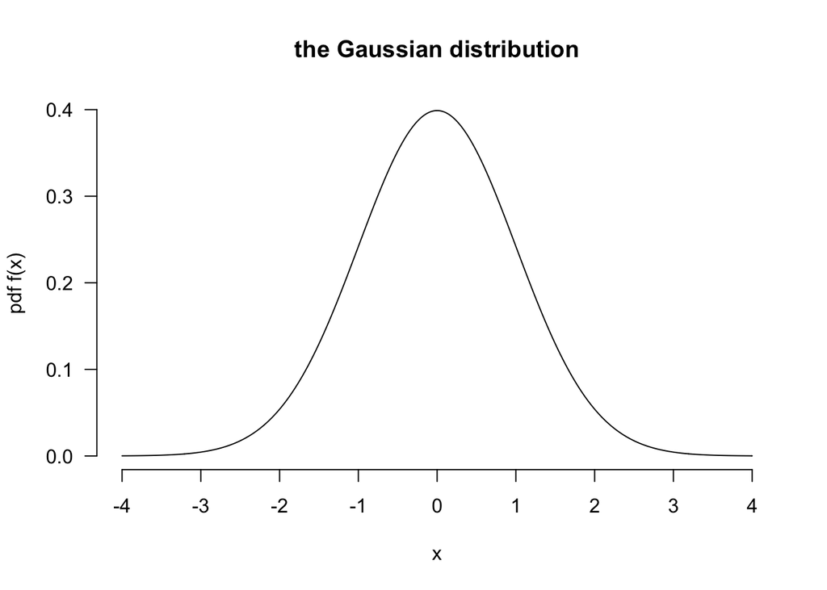

So how does this relate to survival analysis? Well, you should be able to recognize that the cdf is related to the survival function:
$$\begin{aligned}
S(t) & = \text{Pr}(T > t) \\
& = 1 - \text{Pr}(T \le t) \\
& = 1 - F(t)
\end{aligned}$$
which means $f(t) = \frac{d}{dt}F(t) = \frac{d}{dt}(1 - S(t))$.

The hazard is actually defined as
$$\begin{aligned}
\lambda(t) & = -\frac{d}{dt}\log{S(t)} \\
& = \frac{f(t)}{S(t)},
\end{aligned}$$
and the cumulative hazard is $\Lambda(t) = -\log{S(t)}$. So, summing up these relationships:

- $\Lambda(t) = -\log{S(t)}$
- $S(t) = e^{-\Lambda(t)}$
- $\lambda(t) = \frac{f(t)}{S(t)}$
- $f(t) = \lambda(t)S(t)$

**Every** distribution is *uniquely* defined by its cdf $F(t)$ (and thus by $S(t)$ as well). This is why when checking distributional assumptions, we look at Q-Q (quantile-quantile) plots—we want to see how well the empirical cdf of our sample matches the cdf of a Gaussian, exponential, Weibull, or whatever distribution we’ve assumed it follows.

Ok, so why do you care about this again?

Let’s consider an example where our random variable $T$ is the time to an event, and let’s assume here that its hazard is constant over time; i.e., $\lambda(t) = \lambda$. If that’s the case, then $\Lambda(t) = {\lambda}t, S(t) = e^{-{\lambda}t}$, and $F(t) = 1 - e^{-{\lambda}t}$, which is exactly the cdf of a random variable that follows the **exponential distribution**. So $T$ has an exponential distribution, and its pdf is $f(t) = \lambda(t)S(t) = {\lambda}e^{-{\lambda}t}$. When we say that something has a particular distribution, this is what it means!

## Parameters

That’s not the whole story, though. To say something has an exponential distribution isn’t too helpful on its own, just like saying something has a Gaussian distribution doesn’t tell you everything about it. These are just general types of distributions, and you can’t really know any specifics about a particular Gaussian distribution without knowing its mean $\mu$ and standard deviation $\sigma$. The mean and standard deviation are the **parameters** of the Gaussian distribution—in other words, they are what distinguishes one Gaussian distribution from another Gaussian distribution. The only way that two Gaussian distributions can be exactly equal is if $\mu_1 = \mu_2$ **AND** $\sigma_1 = \sigma_2$.

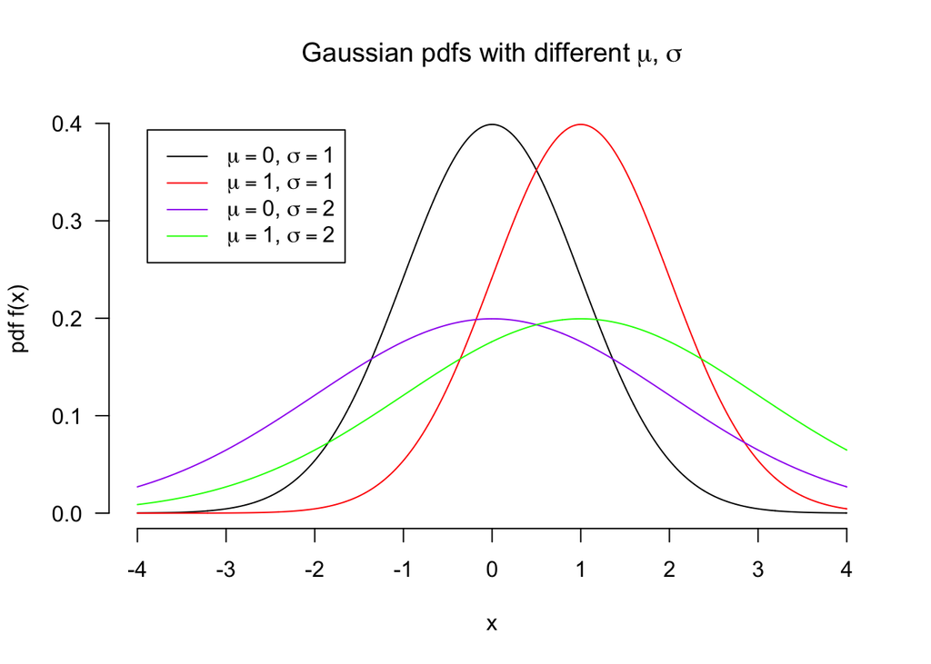

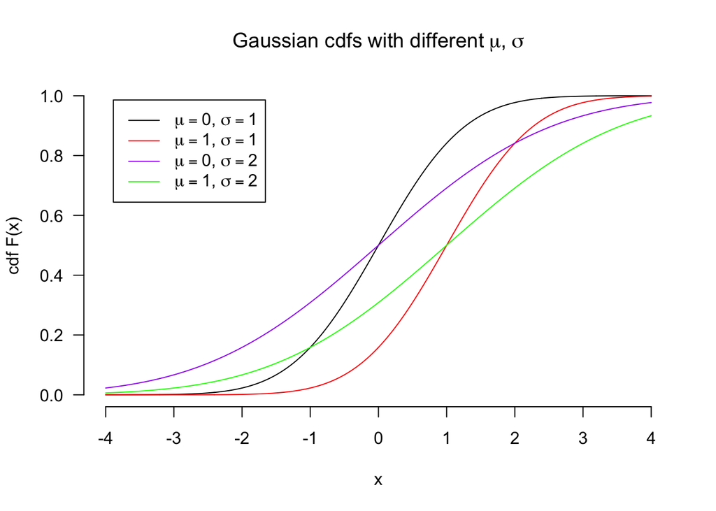

If you take a Gaussian distribution and change its mean, it will still be a Gaussian distribution, but the entire thing is just shifted horizontally by the change in $\mu$. $\mu$ is an example of a **location** parameter. Distributions with that property of still being the same distribution, only shifted in location, belong to a class of distributions called **location families**. For a Gaussian distribution, the location here happens to be its mean $\mu$, but for other distributions, the median or mode could also serve as location parameters. (For example, the Cauchy distribution is a location family, even though its mean is undefined.)

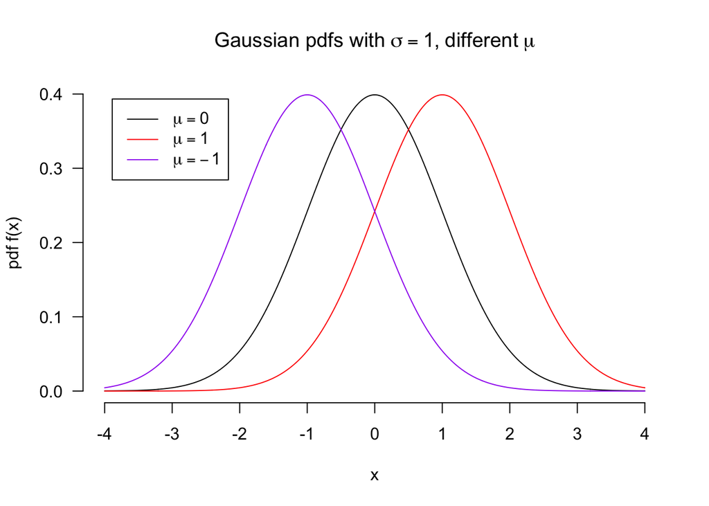

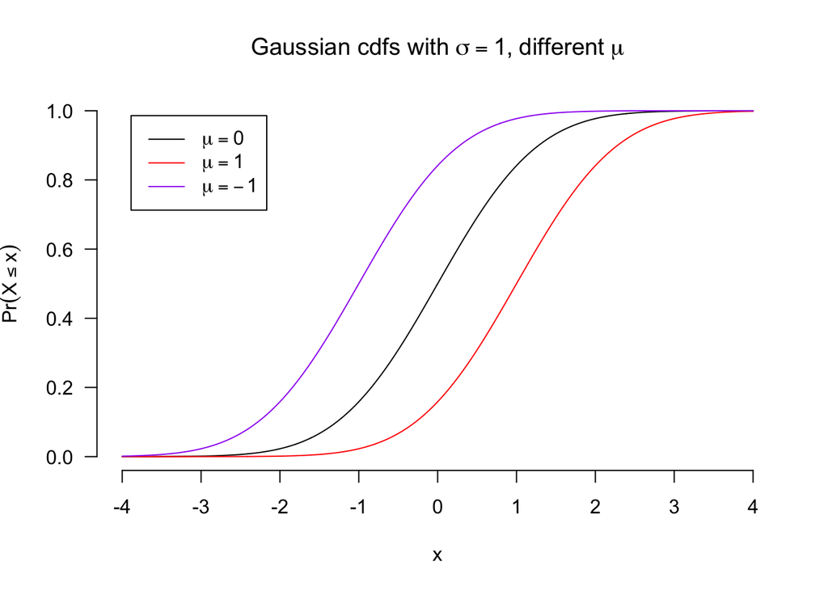

The standard deviation $\sigma$ is an example of a **scale** parameter, which controls the spread/concentration of a distribution’s possible values. We have something similar here to location families where dividing by the scale results in the same distribution, only scaled by $\sigma$—these are called **scale families**. Some distributions are better characterized in terms of the **rate** parameter $\lambda = 1/\sigma$, but the idea is still the same in that it describes the spread: a larger value of the scale $\sigma$ means the values of the distribution are spread out more, so the rate $\lambda$ is low; conversely, a smaller scale $\sigma$ means the distribution’s values are more clustered together, so the rate $\lambda$ is high.

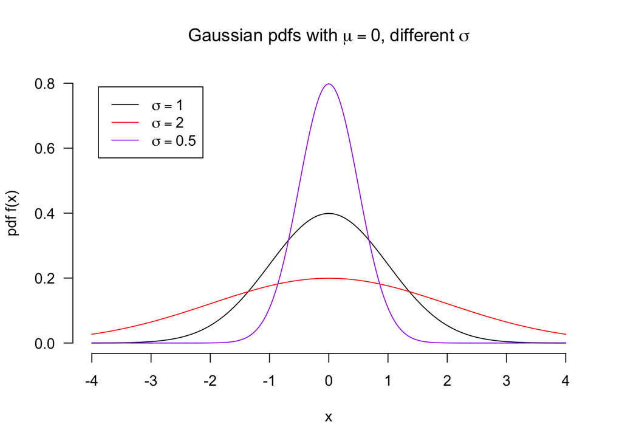

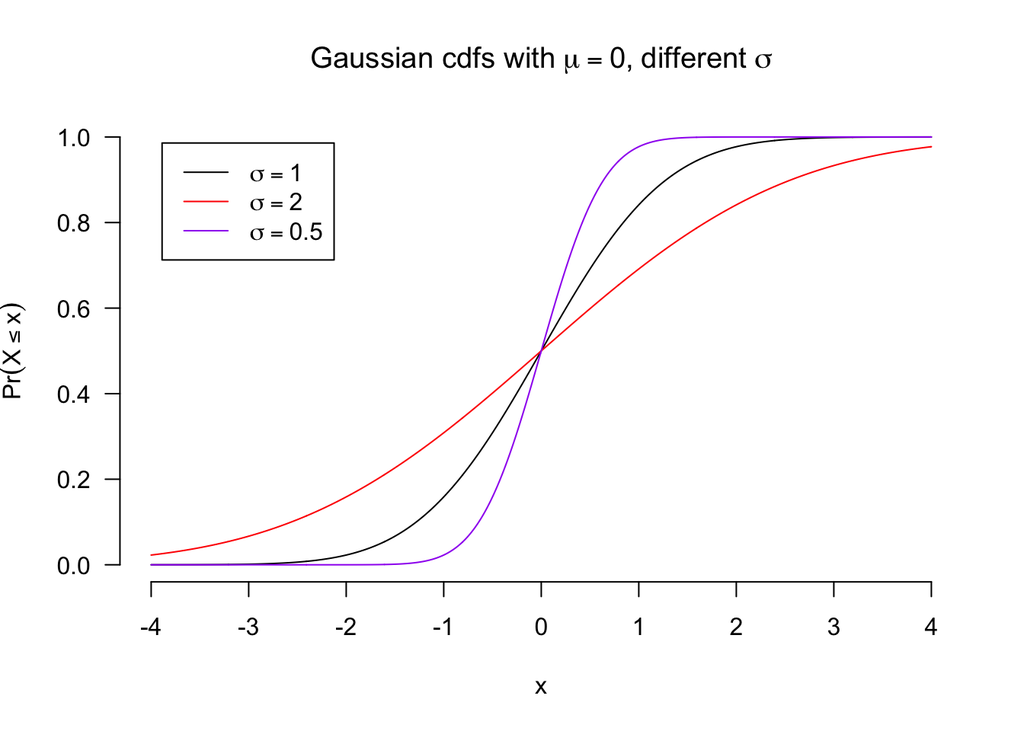

Now, let’s go back to the $z$-test again: we have some random variable $X$ that has a Gaussian distribution with a known mean $\mu$ and SD $\sigma$. For every value of our realized $x$, we can compute the $z$-score $z = \frac{x - \mu}{\sigma}$, which we know comes from the random variable $Z$ that follows a Gaussian distribution with $\mu = 0, \sigma = 1$. Since $Z = \frac{X - \mu}{\sigma}$, then $X = \mu + {\sigma}Z$. Relating this to the cdf, what we’re basically saying is this:
$$\begin{aligned}
\Pr{(X > x)} & = \Pr{(\mu + {\sigma}Z > x)} \\
& = \text{Pr}(Z > \frac{x - \mu}{\sigma})
\end{aligned}$$
So by subtracting the location parameter and dividing by the scale parameter, we still end up with a Gaussian distribution. This is an example of a **location-scale** family, meaning that if a distribution has the pdf $f(x)$, then $\frac{1}{\sigma}f(\frac{x - \mu}{\sigma})$ is also a pdf of that same distribution. In other words, $X$ is a *linear transformation* of $Z$: there is some random variable $Z$ such that $X = \mu + {\sigma}Z$. We know $Z$ as the **standard** Gaussian distribution—“standard” meaning that because $Z$’s location parameter is $0$ and its scale parameter is $1$, we can equivalently turn *any* Gaussian distribution $X$ into $Z$ and vice versa. We’ll come back to it shortly, but remember this part, it’s important.

# The Weibull distribution

## Shape

No matter what the mean and standard deviation are, a Gaussian distribution is still going to have the same general shape—it will always be bell-shaped, it will always be symmetric about $\mu$. So just by knowing that a distribution is Gaussian, you automatically know generally what it will look like, even if you don’t know the specifics of how tall its peak is, how narrow or spread it is, where it’s centered, etc. This isn’t necessarily true for every distribution, though, so instead of a location parameter that just tells us how much something shifts by, some distributions have a parameter that controls the actual shape of the distribution.

If a random variable $T$ has a Weibull distribution, then
$$S(t) = \exp{\{-({\lambda}t)^{\gamma}}\},$$
and
$$\lambda(t) = \lambda\gamma({\lambda}t)^{\gamma - 1}$$
As you can see, the Weibull distribution is parameterized by the **rate** $\lambda$[^1] along with this new **shape parameter** $\gamma$. (Note that if $\gamma = 1$, then $S(t) = e^{-{\lambda}t}$, meaning $T$ has an exponential distribution with rate $\lambda$, which we saw earlier.)

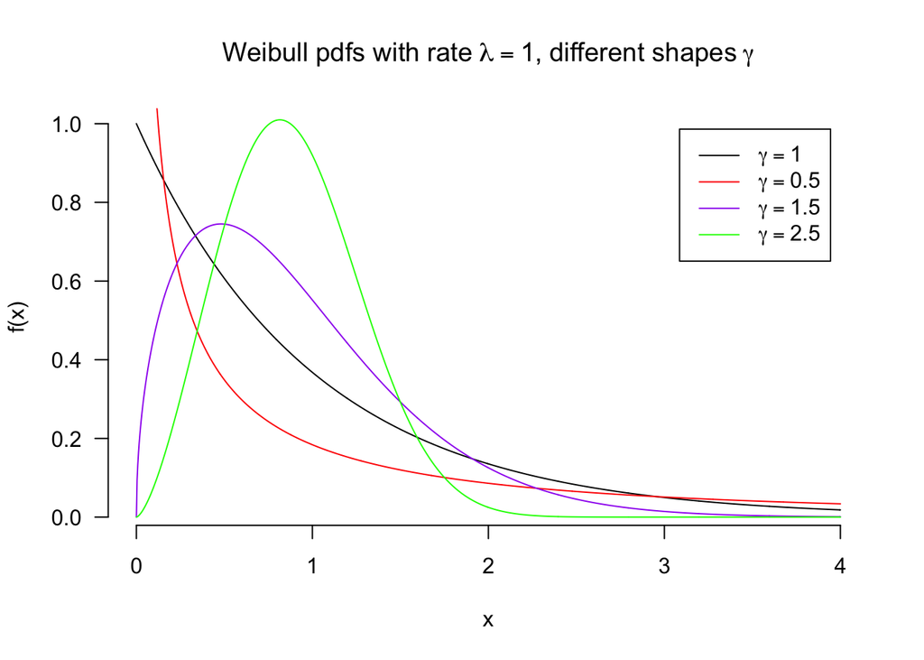

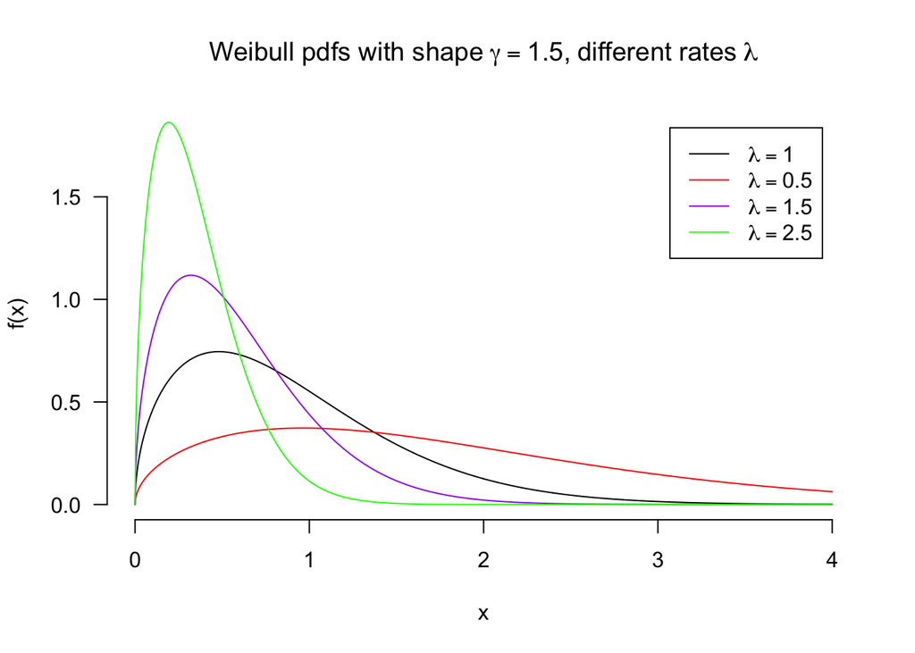

## AFT model

As shown in the pdfs above, the Weibull distribution can only output non-negative values, so that’s probably going to be useful for survival analysis. It also turns out that the Weibull distribution has some nice properties for modeling. In particular, consider the random variable $Y = \log{T}$. We know the following about $Y$:
$$\begin{aligned}
S(y) & = \Pr{(Y > y)} \\
& = \Pr{(\log{T} > y)} \\
& = \Pr{(T > e^{y})},
\end{aligned}$$
so if $T \sim \text{Weibull}(\gamma, \lambda)$, then
$$\begin{aligned}
S(y) & = \Pr{(T > e^{y})} \\
& = \exp{\{-({\lambda}e^{y})^{\gamma}\}}
\end{aligned}$$
Now, let’s define $\mu = -\log{\lambda}$ so that $\lambda = e^{-\mu}$:
$$\begin{aligned}
S(y) & = \exp{\{-({\lambda}e^{y})^{\gamma}\}} \\
& = \exp{\{-(e^{-\mu}e^{y})^{\gamma}\}} \\
& = \exp{\{-(e^{y - \mu})^{\gamma}\}}
\end{aligned}$$
So $Y = \log{T}$ has the survival function of what’s called the *extreme value distribution* (EV). But that’s not the important part—notice that the $y - \mu$ part makes this look like the location family that we discussed earlier. You might guess that we ultimately want to end up with a *standard* EV distribution, so how do we get that?

One more substitution: let $\theta = 1/\gamma$:
$$\begin{aligned}
S(y) & = \exp{\{-(e^{y - \mu})^{\gamma}\}} \\
& = \exp{\{-e^{\gamma(y - \mu)}\}} \\
& = \exp{\{-e^\left(\frac{y - \mu}{\theta}\right)\}}
\end{aligned}$$

So we’ve ended up with the form of a location-scale family where $\mu$ and $\theta$ are the location and scale parameters, respectively. In a standard distribution, we want the location parameter to be $0$ and the scale parameter to be $1$. Consider what that means here:

- When $\mu = 0$, then $\lambda = e^{0} = 1$. So our corresponding Weibull distribution has rate $\lambda = 1$.
- When $\theta = 1$, then $\gamma = 1$. But remember that if $\gamma = 1$, our corresponding Weibull distribution with $\lambda = 1$ is actually an **exponential distribution** with $\lambda = 1$. So for $Y = \log{T}$, the exponential distribution represents a scale family, and if $T \sim \text{Exp}(\lambda = 1)$, then we have a standard EV distribution with $\mu = -\log{1} = 0$ and $\theta = 1$.

So really, an $\text{Exp}(\lambda = 1)$ distribution is, on the log scale, a standard EV distribution. And this is how we’ve ended up with the form of a location-scale family, meaning we have $Y = \log{T} = \mu + \theta\varepsilon$, where

- $\mu = -\log{\lambda}$
- $\theta = 1/\gamma$
- $\varepsilon$ follows a standard extreme value distribution with location parameter $0$ and scale parameter $1$

Remember that in an AFT model, the predictors rescale time:
$$T_i = T_{0}e^{\eta_i},\,\text{with}\, \eta_i = \boldsymbol{x}_{i}^{T}\boldsymbol{\beta}$$
On the log scale, this gives:
$$\begin{aligned}
\log{T_i} & = \eta_i + \log{T_0} \\
& = \mu_i + \theta\varepsilon_i,
\end{aligned}$$
where $\mu_i = -\log{\lambda_i} = \eta_i = \boldsymbol{x}_{i}^{T}\boldsymbol{\beta}, \theta = 1/\gamma$, and $\varepsilon_i$ follows a standard extreme value distribution. So each $T_i$ follows its own Weibull distribution with the same shape $\gamma$ but different rates $\lambda_i = e^{-\eta_i}$ (or scales $\sigma_i = 1/{\lambda_i} = e^{\eta_i}$) which depend on the individual predictor values $\boldsymbol{x}_{i}$.

In `R`, the `*survreg()` functions use the location-scale parameterization, while the `*weibull()` functions use the shape-scale parameterization. And stupidly enough, the `*exp()` functions in `R` use the rate parameterization. But it is important to keep in mind that the shape-scale “scale” is not the same number as the location-scale “scale.”

Furthermore, consider what the intercept $\beta_0$ represents here: if all $x_j = 0$, then $\eta_i = \beta_0$, so $\mu_i = -\log{\lambda}$ is the same for all $i$. So as stated in class, $-\log{\lambda}$ is the “intercept” in `survreg()` and `proc lifereg`. And once again, the “scale” in `survreg()` and `proc lifereg` is $1/\gamma$, which is what I’m calling $\theta$ here.

Finally, the substitution $\theta = 1/\gamma$ also gives a interesting connection that you may notice in your model output: the shape and scale estimates are reciprocals of each other. Again, consider the exponential distribution as a Weibull distribution parameterized by $(\lambda, \gamma)$. Only one of those parameters actually needs to be estimated here: the rate $\lambda$, because the shape $\gamma$ is fixed at $1$; alternatively, in the location-scale parameterization, we only need to estimate $\mu$ since $\theta$ is also fixed at $1$. But typically, the Weibull distribution has two parameters to be estimated: the rate $\lambda$ and the shape $\gamma$ in the shape-rate parameterization, or the mean $\mu$ and scale $\theta$ in the location-scale parameterization. Since $\theta = 1/\gamma$, it’s sufficient to just estimate either $\gamma$ **or** $\theta$. However, for the Generalized Gamma distribution, which I mentioned in class includes the Weibull as a special case, $\theta$ is estimated separately as a third parameter, where we do not enforce the $\theta = 1/\gamma$ constraint.

## Proportional hazards model

The last thing I’ll briefly cover about the Weibull distribution is why it’s both an AFT model and a proportional hazards (PH) model, but first, let’s understand why models are either one or the other, but not both.

Recall that in an AFT model, the predictors rescale on the hazard like so:
$$\lambda_{i}(t) = \lambda_{0}(te^{-\eta_i})e^{-\eta_i}$$
In a PH model, the predictors directly affect the hazard rather than time:
$$\lambda_{i}(t) = \lambda_{0}(t)e^{\eta_i}$$
When comparing two observations $\boldsymbol{x}_1, \boldsymbol{x}_2$ in a PH model by taking the hazard ratio $\frac{\lambda_{2}(t)}{\lambda_{1}(t)}, \lambda_{0}(t)$ cancels out and the hazard ratio is constant over time—literally the definition of “proportional hazards.” But in the AFT model, that doesn’t happen, as the hazard ratio still depends on $t$ in addition to $\eta_1, \eta_2$. To compare the models visually, we can plot their responses—$\log{\lambda(t)}$ vs. $\log{T}$:

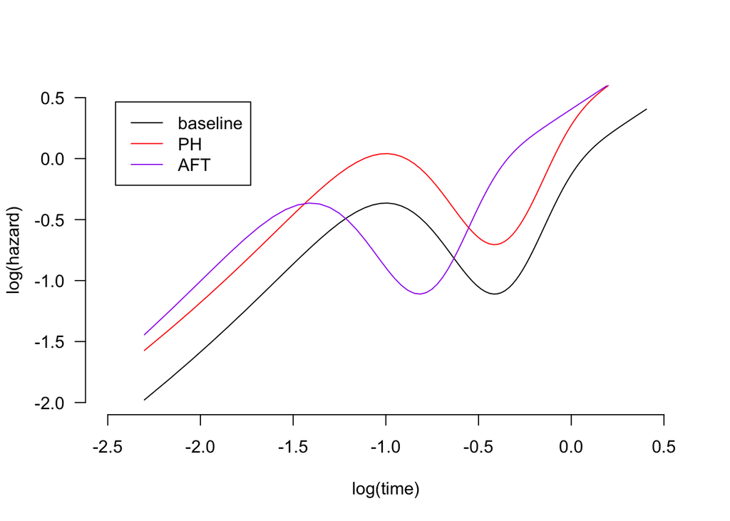

From the plot, we can see that AFT and PH models correspond to horizontal shifts (scaling time) and vertical shifts (scaling the hazard), respectively. Thus, these two models have two different—and incompatible—sets of assumptions; a single model can turn the black line into either the red line or the purple line, but not both. The only way to satisfy both assumptions simultaneously is when the distribution of $T$ is linear on the scale of both log(hazard) and log(time).

We’ve already seen that if $T \sim \text{Weibull}(\gamma, \lambda)$, then $Y = \log{T}$ is a linear transformation of an extreme value distribution; i.e., $Y = \mu + \theta\varepsilon$. Let’s revisit the survival function for that EV distribtion:
$$S(y) = \exp{\{-e^\left(\frac{y - \mu}{\theta}\right)\}}$$
which means
$$\begin{aligned}
\lambda(y) & = -\frac{d}{dy}\log{S(y)} \\
& = \frac{\exp{\{(\frac{y - \mu}{\theta})}\}}{\theta}\\
& = e^{\varepsilon}/\theta,
\end{aligned}$$
where $\varepsilon = \frac{y - \mu}{\theta}$, so $\log{\lambda(y)} = \log{(e^{\varepsilon}/\theta)} = \varepsilon - \log{\theta}$. Thus, the Weibull distribution meets both linearity assumptions simultaneously and is, in fact, the only distribution that does so.

Now that we’ve shown this, we can derive the relationship between the Weibull AFT and PH models. If $T \sim \text{Weibull}(\gamma, \lambda)$, then $\lambda_{0}(t) = \lambda\gamma({\lambda}t)^{\gamma - 1}$, so the associated proportional hazards model is
$$\lambda_{i}(t) = \lambda\gamma({\lambda}t)^{\gamma - 1}e^{\boldsymbol{x}_{i}^{T}\boldsymbol{\beta}_{PH}}$$
and the hazard for the AFT model is
$$\lambda_{i}(t) = \lambda\gamma({\lambda}te^{-\boldsymbol{x}_{i}^{T}\boldsymbol{\beta}_{AFT}})^{\gamma - 1}e^{-\boldsymbol{x}_{i}^{T}\boldsymbol{\beta}_{AFT}}$$

Setting these equal to each other:
$$\begin{aligned}
\lambda\gamma({\lambda}t)^{\gamma - 1}e^{\boldsymbol{x}_{i}^{T}\boldsymbol{\beta}_{PH}} & = \lambda\gamma({\lambda}te^{-\boldsymbol{x}_{i}^{T}\boldsymbol{\beta}_{AFT}})^{\gamma - 1}e^{-\boldsymbol{x}_{i}^{T}\boldsymbol{\beta}_{AFT}} \\
\lambda\gamma({\lambda}t)^{\gamma - 1}e^{\boldsymbol{x}_{i}^{T}\boldsymbol{\beta}_{PH}} & = \lambda\gamma({\lambda}t)^{\gamma - 1}(e^{-\boldsymbol{x}_{i}^{T}\boldsymbol{\beta}_{AFT}})^{\gamma - 1}e^{-\boldsymbol{x}_{i}^{T}\boldsymbol{\beta}_{AFT}} \\
e^{\boldsymbol{x}_{i}^{T}\boldsymbol{\beta}_{PH}} & = (e^{-\boldsymbol{x}_{i}^{T}\boldsymbol{\beta}_{AFT}})^{\gamma} \\
e^{\boldsymbol{x}_{i}^{T}\boldsymbol{\beta}_{PH}} & = e^{-\gamma\boldsymbol{x}_{i}^{T}\boldsymbol{\beta}_{AFT}}
\end{aligned}$$
and finally, taking the log of both sides gives $\boldsymbol{x}_{i}^{T}\boldsymbol{\beta}_{PH} = -\gamma\boldsymbol{x}_{i}^{T}\boldsymbol{\beta}_{AFT}$, where the relationship is now clear:
$$\boldsymbol{\beta}_{PH} = -\gamma\boldsymbol{\beta}_{AFT}$$

# The log-logistic distribution

## AFT model

Like the Weibull distribution, the log-logistic distribution is defined by shape and rate/scale parameters. If $T$ follows a log-logistic distribution, then
$$S(t) = [1 + ({\lambda}t)^{\gamma}]^{-1}$$
Recall that in AFT models:
$$\begin{aligned}
T_i & = T_{0}e^{\eta_i} \\
\Rightarrow S_{i}(t) & = S_{0}(te^{-\eta_i})
\end{aligned}$$

## Proportional odds model

Using a general AFT model, consider instead what the odds of failure before time $t$ look like:
$$\begin{aligned}
\frac{\Pr{(T \le t)}}{1 - \Pr{(T \le t)}} & = \frac{\Pr{(T \le t)}}{\Pr{(T > t)}} \\
& = \frac{1 - S_{0}(te^{-\eta_i})}{S_{0}(te^{-\eta_i})}
\end{aligned}$$
If $T$ has a log-logistic distribution, the odds of failure are
$$\begin{aligned}
\frac{1 - S_{0}(te^{-\eta_i})}{S_{0}(te^{-\eta_i})} & = \frac{1 - [1 + ({\lambda}te^{-\eta_i})^{\gamma}]^{-1}}{[1 + ({\lambda}te^{-\eta_i})^{\gamma}]^{-1}} \\
& = ([1 + ({\lambda}te^{-\eta_i})^{\gamma}]^{-1})^{-1} - 1 \\
& = ({\lambda}te^{-\eta_i})^{\gamma}
\end{aligned}$$
Then, for two people $\{\boldsymbol{x}_1, \boldsymbol{x}_2\}$ the odds ratio of failure is
$$\begin{aligned}
\frac{({\lambda}te^{-\eta_1})^{\gamma}}{({\lambda}te^{-\eta_2})^{\gamma}} & = \frac{\exp\{{-\gamma\eta_1}\}}{\exp\{{-\gamma\eta_2}\}} \\
& = \exp\{{\gamma(\eta_2 - \eta_1)}\} \\
& = \exp\{{\gamma(\boldsymbol{x}_{2} - \boldsymbol{x}_1)^{T}\boldsymbol{\beta}}\},
\end{aligned}$$
which is independent of $t$, so the effect of the predictors on the odds of failure is the same at all times.

So, we can use ordinal logistic regression to model the $\log{(\text{odds})}$ of failure directly:
$$\begin{aligned}
\log{\left(\frac{\Pr{(T \le t)}}{\Pr{(T > t)}}\right)} & = \log{\left(\frac{1 - S_{0}(te^{-\eta_i})}{S_{0}(te^{-\eta_i})}\right)} \\
& = \log{\left(({\lambda}te^{-\eta_i})^{\gamma}\right)} \\
& = \gamma\log{({\lambda}t)} - \gamma\boldsymbol{x}_{i}^{T}\boldsymbol{\beta}
\end{aligned}$$

The log-logistic is the only distribution for which an AFT model is also a proportional odds model.

[^1]: As stated in class, we can also define the Weibull in terms of the scale parameter $\sigma = 1/\lambda$, where $S(t) = \exp{\{-(t/\sigma)^{\gamma}}\}, \lambda(t) = (\frac{\gamma}{\sigma})(\frac{t}{\sigma})^{\gamma - 1}$. It’s easier to write (and more intuitive to follow, in my opinion) the rate parameterization, so that’s why I’ve chosen to use it in class.